# Métodos Numéricos Aplicados a Finanças — Turma 2025

Aula 12

Prof. Frega PPGOLD/Universidade Federal do Paraná

27/05/2025

```r
library(magrittr)
.sgouttype = ifelse(!is.null(knitr::opts_knit$get("out.format")), "html", "text")
.stargazertype = .sgouttype
source("https://raw.githubusercontent.com/jrfrega/2025/refs/heads/main/mhist.R")
library(stargazer)
library(nlWaldTest) # for the `nlWaldtest()` function
library(lmtest) #for `coeftest()` and `bptest()`.
library(broom) #for `glance(`) and `tidy()`
library(PoEdata) #for PoE4 datasets
library(car) #for `hccm()` robust standard errors
library(sandwich)
library(knitr) #for `kable()`
library(forecast)
library(AER)
library(xtable)
```

# 1 Chapter 16 Qualitative and LDV Models

y é uma variável qualitativa, ou seja 0 representa uma categoria e 1 representa outra categoria. Não é uma relação numérica. $(0\ne1)$

$$y = \beta_0 + \beta_1\ x_1 + \beta_2\ x_2 + \beta_3\ x_3 + \dots + \beta_k\ x_k + e$$

Este é um procedimento de classificação: dados os valores de $x$, infere-se que o $y$ pertença à categoria 0 ou à categoria 1 por meio do $\widehat{y}$.

Vamos começar com uma regressão binária (ou seja, y pode assumir um dentre dois valores, usualmente representados por 0 e 1).

```r
discretize = function(x, levels = 5) {
  cut(x, levels) %>% as.numeric
}
set.seed(22)
# Gerando valores aleatórios
N = 50
cf = c(1, 0, 2, 0, -1)
m = NULL
for(i in 1:5) {
  m = cbind(m, discretize(rnorm(N)))
}
y = (m%*%cf + rnorm(N)) %>% discretize(2) - 1
m = cbind(y, m)
colnames(m) = c("y", paste("x", 1:5, sep = ""))
head(m)
```

```
##      y x1 x2 x3 x4 x5
## [1,] 0  2  1  1  2  4
## [2,] 1  5  3  2  3  1
## [3,] 0  3  1  2  4  1
## [4,] 1  2  3  4  5  2
## [5,] 1  2  5  3  3  1
## [6,] 1  4  3  3  3  2
```

Modelo baseado em uma regressão linear é chamado de modelo discriminante linear

```r
m1 = lm(y~x1+x2+x3+x4+x5, data = m %>% as.data.frame)
# m1 = lm(y~., data = m %>% as.data.frame)
m1 %>% summary
```

```
##
## Call:
## lm(formula = y ~ x1 + x2 + x3 + x4 + x5, data = m %>% as.data.frame)
##
## Residuals:
##      Min       1Q   Median       3Q      Max
## -0.67260 -0.23890 -0.02563  0.20101  0.69345
##
## Coefficients:
##             Estimate Std. Error t value Pr(>|t|)
## (Intercept) -0.11755    0.22610  -0.520    0.606
## x1           0.19200    0.04318   4.447 5.85e-05 ***
## x2           0.04066    0.03724   1.092    0.281
## x3           0.28447    0.03984   7.140 7.14e-09 ***
## x4          -0.04670    0.04434  -1.053    0.298
## x5          -0.20867    0.04386  -4.758 2.14e-05 ***
## ---
## Signif. codes:  0 '***' 0.001 '**' 0.01 '*' 0.05 '.' 0.1 ' ' 1
##
## Residual standard error: 0.3114 on 44 degrees of freedom
## Multiple R-squared:  0.6566, Adjusted R-squared:  0.6175
## F-statistic: 16.82 on 5 and 44 DF,  p-value: 2.851e-09
```

```r
# vejamos os yhat
m1$fitted.values %>% head
```

```
##          1          2          3          4          5          6
## -0.3365049  1.1846238  0.6725994  0.8754851  0.9744048  1.0684152
```

```r
# vamos mostra os valores originais
m[, "y"] %>% head
```

```
## [1] 0 1 0 1 1 1
```

```r
# vamos comparar os dois
cbind(yhat = m1$fitted.values, y = m[, "y"]) %>% head
```

```
##         yhat y
## 1 -0.3365049 0
## 2  1.1846238 1
## 3  0.6725994 0
## 4  0.8754851 1
## 5  0.9744048 1
## 6  1.0684152 1
```

```r
# modelo de classificação previsto x observado
cbind(yhat = m1$fitted.values >= 0.5, y = m[, "y"]) -> classific
classific %>% head
```

```
##   yhat y
## 1    0 0
## 2    1 1
## 3    1 0
## 4    1 1
## 5    1 1
## 6    1 1
```

```r
# gerar a matriz de confusão (confusion matrix)
classific %>% as.data.frame %>% table %>% t
```

```
##    yhat
## y    0  1
##   0 22  1
##   1  3 24
```

```r
# quais são os casos em que a previsão errou
which(classific[,1]!=classific[,2]) -> errou
errou %>% as.numeric()
```

```
## [1]  3  9 11 25
```

```r
m[errou,]
```

```
##      y x1 x2 x3 x4 x5
## [1,] 0  3  1  2  4  1
## [2,] 1  2  4  2  2  2
## [3,] 1  1  2  3  2  2
## [4,] 1  2  3  2  5  2
```

## 1.1 Probit

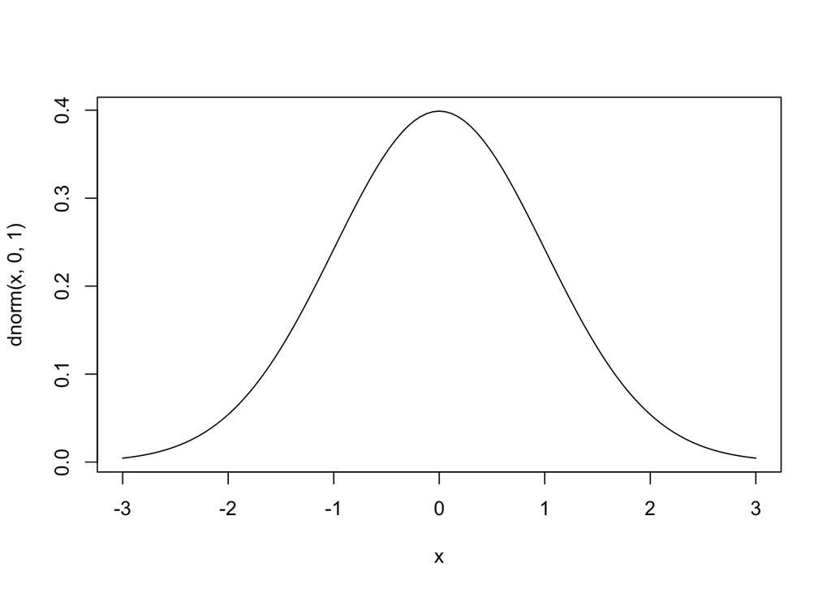

```r
curve(dnorm(x, 0, 1), xlim = c(-3, 3))
```

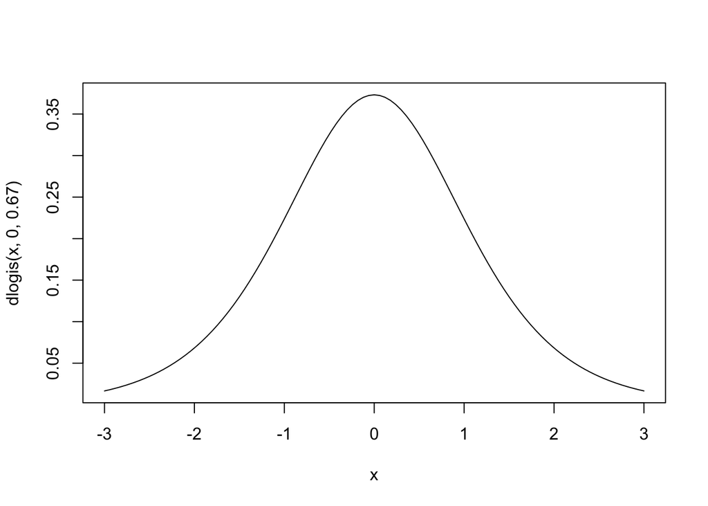

```r
curve(dlogis(x, 0, 0.67), xlim = c(-3, 3))
```

Define-se $\Phi(y)$ como a função densidade acumulada da distribuição normal.

$$y = \beta_0 + \beta_1\ x_1 + \beta_2\ x_2 + \beta_3\ x_3 + \dots + \beta_k\ x_k + e\\[1em]
\hat{p} = \Phi(y)$$

todos os valores previstos na regressão podem ser enxergados como probabilidades, pois estão em um intervalo $[0,\ 1]$

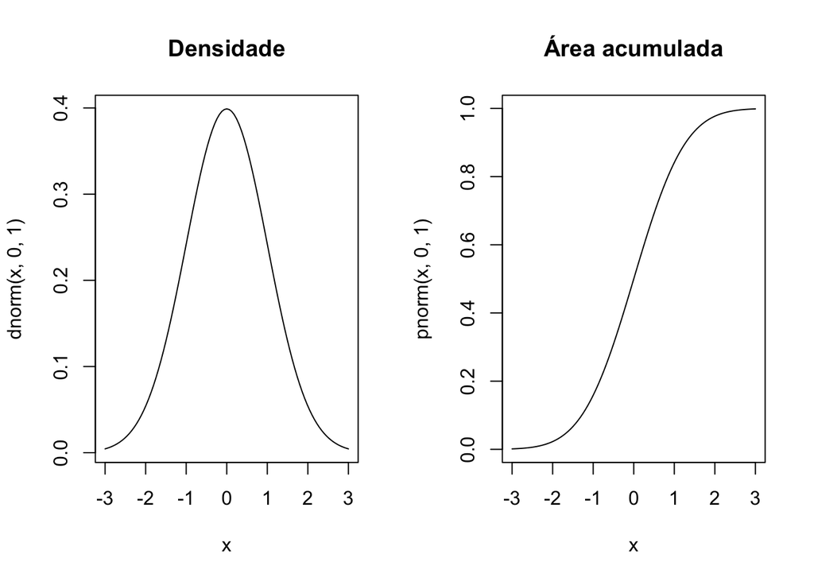

```r
layout(1:2 %>% matrix(ncol = 2))
curve(dnorm(x, 0, 1), xlim = c(-3, 3), main = "Densidade")
curve(pnorm(x, 0, 1), xlim = c(-3, 3), main = "Área acumulada")
```

```r
m
```

```
##       y x1 x2 x3 x4 x5
##  [1,] 0  2  1  1  2  4
##  [2,] 1  5  3  2  3  1
##  [3,] 0  3  1  2  4  1
##  [4,] 1  2  3  4  5  2
##  [5,] 1  2  5  3  3  1
##  [6,] 1  4  3  3  3  2
##  [7,] 0  2  5  4  3  5
##  [8,] 1  2  1  4  4  3
##  [9,] 1  2  4  2  2  2
## [10,] 0  2  2  2  3  3
## [11,] 1  1  2  3  2  2
## [12,] 0  2  5  1  2  2
## [13,] 1  3  2  2  4  1
## [14,] 0  2  2  3  3  4
```

[output cut: 36 more lines]

```r
# Generalized Linear Model - GLM
glm(y~x1+x2+x3+x4+x5, data = m %>% as.data.frame(), family = binomial(link = "probit")) -> m2
summary(m2)
```

```
##
## Call:
## glm(formula = y ~ x1 + x2 + x3 + x4 + x5, family = binomial(link = "probit"),
##     data = m %>% as.data.frame())
##
## Coefficients:
##             Estimate Std. Error z value Pr(>|z|)
## (Intercept)  -5.7461     2.2827  -2.517  0.01183 *
## x1            1.3034     0.4651   2.803  0.00507 **
## x2            0.8727     0.4608   1.894  0.05823 .
## x3            2.8127     1.0198   2.758  0.00581 **
## x4           -0.3308     0.3186  -1.038  0.29914
## x5           -2.2645     0.8799  -2.574  0.01007 *
## ---
## Signif. codes:  0 '***' 0.001 '**' 0.01 '*' 0.05 '.' 0.1 ' ' 1
##
## (Dispersion parameter for binomial family taken to be 1)
##
##     Null deviance: 68.994  on 49  degrees of freedom
## Residual deviance: 16.100  on 44  degrees of freedom
## AIC: 28.1
##
## Number of Fisher Scoring iterations: 10
```

```r
# vejamos os yhat
m2$fitted.values %>% head
```

```
##            1            2            3            4            5            6
## 2.220446e-16 1.000000e+00 8.587286e-01 9.999973e-01 1.000000e+00 9.999997e-01
```

```r
# vamos mostra os valores originais
m[, "y"] %>% head
```

```
## [1] 0 1 0 1 1 1
```

```r
# vamos comparar os dois
cbind(yhat = m2$fitted.values, y = m[, "y"]) %>% head
```

```
##           yhat y
## 1 2.220446e-16 0
## 2 1.000000e+00 1
## 3 8.587286e-01 0
## 4 9.999973e-01 1
## 5 1.000000e+00 1
## 6 9.999997e-01 1
```

```r
# modelo de classificação previsto x observado
cbind(yhat = m2$fitted.values >= 0.5, y = m[, "y"]) -> classific
classific %>% head
```

```
##   yhat y
## 1    0 0
## 2    1 1
## 3    1 0
## 4    1 1
## 5    1 1
## 6    1 1
```

```r
# gerar a matriz de confusão (confusion matrix)
classific %>% as.data.frame %>% table %>% t
```

```
##    yhat
## y    0  1
##   0 21  2
##   1  2 25
```

```r
# quais são os casos em que a previsão errou
which(classific[,1]!=classific[,2]) -> errou
errou %>% as.numeric()
```

```
## [1]  3  7 21 25
```

```r
m[errou,]
```

```
##      y x1 x2 x3 x4 x5
## [1,] 0  3  1  2  4  1
## [2,] 0  2  5  4  3  5
## [3,] 1  2  2  3  1  3
## [4,] 1  2  3  2  5  2
```

## 1.2 16.3 The Transportation Example

```r
data("transport", package="PoEdata")
?transport
# quanto maior o dtime (bus time - auto time)/10, mais terei preferência pelo auto
auto.probit <- glm(auto~dtime, family=binomial(link="probit"),
                   data=transport)
summary(auto.probit)
```

```
##
## Call:
## glm(formula = auto ~ dtime, family = binomial(link = "probit"),
##     data = transport)
##
## Coefficients:
##             Estimate Std. Error z value Pr(>|z|)
## (Intercept) -0.06443    0.40068  -0.161  0.87224
## dtime        0.29999    0.10290   2.915  0.00355 **
## ---
## Signif. codes:  0 '***' 0.001 '**' 0.01 '*' 0.05 '.' 0.1 ' ' 1
##
## (Dispersion parameter for binomial family taken to be 1)
##
##     Null deviance: 29.065  on 20  degrees of freedom
## Residual deviance: 12.330  on 19  degrees of freedom
## AIC: 16.33
##
## Number of Fisher Scoring iterations: 7
```

## 1.3 16.4 The Logit Model for Binary Choice

Hosmer & Lemeshow

$$y = \beta_0 + \beta_1\ x_1 + \beta_2\ x_2 + \beta_3\ x_3 + \dots + \beta_k\ x_k + e\\[1em]
\hat{p} = \Lambda(y) = \dfrac{1}{1+e^{-y}} = \dfrac{e^y}{1+e^y}$$

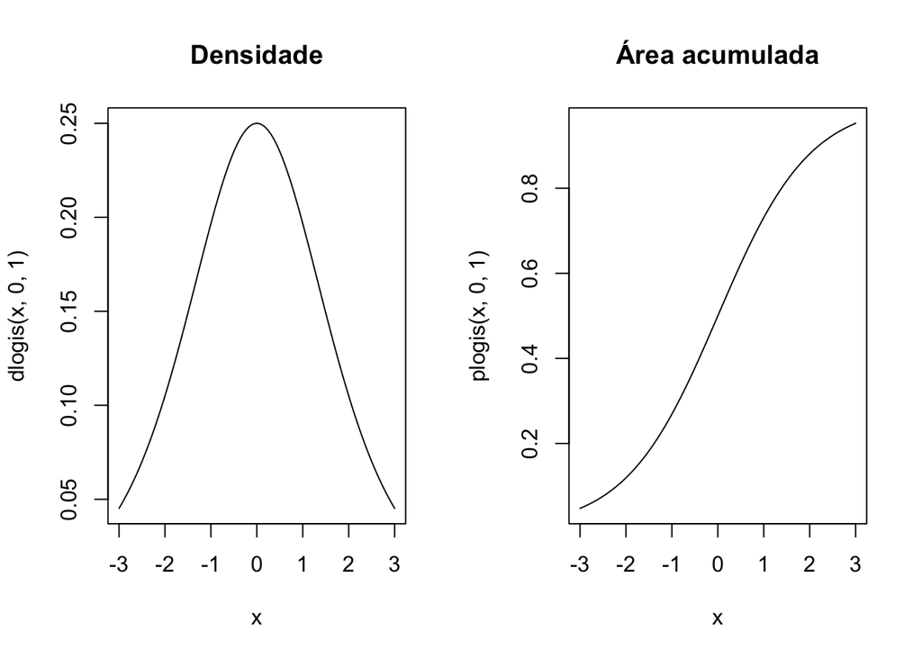

```r
layout(1:2 %>% matrix(ncol = 2))
curve(dlogis(x, 0, 1), xlim = c(-3, 3), main = "Densidade")
curve(plogis(x, 0, 1), xlim = c(-3, 3), main = "Área acumulada")
```

```r
m
```

```
##       y x1 x2 x3 x4 x5
##  [1,] 0  2  1  1  2  4
##  [2,] 1  5  3  2  3  1
##  [3,] 0  3  1  2  4  1
##  [4,] 1  2  3  4  5  2
##  [5,] 1  2  5  3  3  1
##  [6,] 1  4  3  3  3  2
##  [7,] 0  2  5  4  3  5
##  [8,] 1  2  1  4  4  3
##  [9,] 1  2  4  2  2  2
## [10,] 0  2  2  2  3  3
## [11,] 1  1  2  3  2  2
## [12,] 0  2  5  1  2  2
## [13,] 1  3  2  2  4  1
## [14,] 0  2  2  3  3  4
```

[output cut: 36 more lines]

```r
# Generalized Linear Model - GLM
glm(y~x1+x2+x3+x4+x5, data = m %>% as.data.frame(), family = binomial(link = "logit")) -> m3
summary(m3)
```

```
##
## Call:
## glm(formula = y ~ x1 + x2 + x3 + x4 + x5, family = binomial(link = "logit"),
##     data = m %>% as.data.frame())
##
## Coefficients:
##             Estimate Std. Error z value Pr(>|z|)
## (Intercept)  -9.7869     4.2145  -2.322   0.0202 *
## x1            2.2900     0.9095   2.518   0.0118 *
## x2            1.4979     0.8649   1.732   0.0833 .
## x3            4.9146     1.9650   2.501   0.0124 *
## x4           -0.6293     0.5827  -1.080   0.2802
## x5           -3.9912     1.7021  -2.345   0.0190 *
## ---
## Signif. codes:  0 '***' 0.001 '**' 0.01 '*' 0.05 '.' 0.1 ' ' 1
##
## (Dispersion parameter for binomial family taken to be 1)
##
##     Null deviance: 68.994  on 49  degrees of freedom
## Residual deviance: 16.321  on 44  degrees of freedom
## AIC: 28.321
##
## Number of Fisher Scoring iterations: 8
```

```r
# vejamos os yhat
m3$fitted.values %>% head
```

```
##            1            2            3            4            5            6
## 1.105404e-07 9.999592e-01 8.701004e-01 9.995971e-01 9.999856e-01 9.998400e-01
```

```r
# vamos mostra os valores originais
m[, "y"] %>% head
```

```
## [1] 0 1 0 1 1 1
```

```r
# vamos comparar os dois
cbind(yhat = m3$fitted.values, y = m[, "y"]) %>% head
```

```
##           yhat y
## 1 1.105404e-07 0
## 2 9.999592e-01 1
## 3 8.701004e-01 0
## 4 9.995971e-01 1
## 5 9.999856e-01 1
## 6 9.998400e-01 1
```

```r
# modelo de classificação previsto x observado
cbind(yhat = m3$fitted.values >= 0.5, y = m[, "y"]) -> classific
classific %>% head
```

```
##   yhat y
## 1    0 0
## 2    1 1
## 3    1 0
## 4    1 1
## 5    1 1
## 6    1 1
```

```r
# gerar a matriz de confusão (confusion matrix)
classific %>% as.data.frame %>% table %>% t
```

```
##    yhat
## y    0  1
##   0 21  2
##   1  2 25
```

```r
# quais são os casos em que a previsão errou
which(classific[,1]!=classific[,2]) -> errou
errou %>% as.numeric()
```

```
## [1]  3  7 21 25
```

```r
m[errou,]
```

```
##      y x1 x2 x3 x4 x5
## [1,] 0  3  1  2  4  1
## [2,] 0  2  5  4  3  5
## [3,] 1  2  2  3  1  3
## [4,] 1  2  3  2  5  2
```

Logit é computacionalmente mais eficiente que o Probit.

## Construção x validação

Não se deve validar o modelo usando os mesmos dados com o qual ele foi construído, ou seja, se calcularmos o yhat a partir da mesma amostra que usamos para calcular o modelo, ele estará trabalhando em cima de dados conhecidos (validade interna). Se usarmos uma parte dos dados para construir o modelo e a outra parte para validá-lo, teremos a validade externa do modelo.

Exemplo:

```r
discretize = function(x, levels = 5) {
  cut(x, levels) %>% as.numeric
}
set.seed(231)
# Gerando valores aleatórios
N = 500
cf = c(1, 0, 2, 0, -1)
m = NULL
for(i in 1:5) {
  m = cbind(m, discretize(rnorm(N)))
}
y = (m%*%cf + rnorm(N)) %>% discretize(2) - 1
m = cbind(y, m)
colnames(m) = c("y", paste("x", 1:5, sep = ""))
head(m)
```

```
##      y x1 x2 x3 x4 x5
## [1,] 0  3  3  3  2  4
## [2,] 0  1  2  2  2  3
## [3,] 1  2  3  4  3  3
## [4,] 1  3  3  4  2  4
## [5,] 1  3  2  3  3  3
## [6,] 0  3  4  1  4  4
```

```r
m %>% nrow * 0.70 -> nconstroi
sample(1:nrow(m), nconstroi) -> w
# este conjunto vai construir o modelo
constroi = m[w, ] %>% as.data.frame
# este aqui vai validar o modelo
valida = m[-w, ] %>% as.data.frame
m4 = glm(y~., data = constroi, family = binomial(link = "logit"))
# se usar o conjunto de construção para validar, terei uma validação interna
predict(m4, newdata = constroi, type = "response") -> yhat
data.frame(y = constroi$y, yhat = (yhat > 0.5) %>% as.numeric) %>% table -> t
(t/rowSums(t)) %>% round(4) * 100 -> torigperc
torigperc
```

```
##    yhat
## y       0     1
##   0 90.34  9.66
##   1 11.89 88.11
```

```r
torig = t
# a validação real é conseguida por meio da previsão sobre o conjunto de validação
predict(m4, newdata = valida, type = "response") -> yhat
data.frame(y = valida$y, yhat = (yhat > 0.5) %>% as.numeric) %>% table -> t
(t/rowSums(t)) %>% round(4) * 100
```

```
##    yhat
## y       0     1
##   0 92.47  7.53
##   1  3.51 96.49
```

```r
library(rr2)
rr2::R2(m4)
```

```
##    R2_lik  R2_resid   R2_pred
## 0.5785487 0.6881139 0.6805723
```

```r
blorr::blr_model_fit_stats(m4)
```

```
##                               Model Fit Statistics
## ---------------------------------------------------------------------------------
## Log-Lik Intercept Only:      -236.717    Log-Lik Full Model:              -85.508
## Deviance(344):                171.016    LR(5):                           302.418
##                                          Prob > LR:                         0.000
## MCFadden's R2                   0.639    McFadden's Adj R2:                 0.613
## ML (Cox-Snell) R2:              0.579    Cragg-Uhler(Nagelkerke) R2:        0.780
## McKelvey & Zavoina's R2:        0.859    Efron's R2:                        0.681
## Count R2:                       0.894    Adj Count R2:                      0.741
## BIC:                          206.164    AIC:                             183.016
## ---------------------------------------------------------------------------------
```

```r
torig %>% t
```

```
##     y
## yhat   0   1
##    0 187  17
##    1  20 126
```

```r
torigperc
```

```
##    yhat
## y       0     1
##   0 90.34  9.66
##   1 11.89 88.11
```

```r
blorr::blr_confusion_matrix(m4)
```

```
## Confusion Matrix and Statistics
##
##           Reference
## Prediction   0   1
##          0 187  17
##          1  20 126
##
##
##                 Accuracy : 0.8943
##      No Information Rate : 0.5914
##
##                    Kappa : 0.7820
##
## McNemars's Test P-Value  : 0.7423
##
##              Sensitivity : 0.8811
##              Specificity : 0.9034
##           Pos Pred Value : 0.8630
##           Neg Pred Value : 0.9167
##               Prevalence : 0.4086
##           Detection Rate : 0.3600
##     Detection Prevalence : 0.4171
##        Balanced Accuracy : 0.8923
##                Precision : 0.8630
##                   Recall : 0.8811
##
##         'Positive' Class : 1
```

```r
# O teste de Hosmer-Lemeshow tem H0: o modelo está bem ajustado aos dados
ResourceSelection::hoslem.test(m4$model$y, m4$fitted.values)
```

```
##
##  Hosmer and Lemeshow goodness of fit (GOF) test
##
## data:  m4$model$y, m4$fitted.values
## X-squared = 3.4353, df = 8, p-value = 0.9042
```

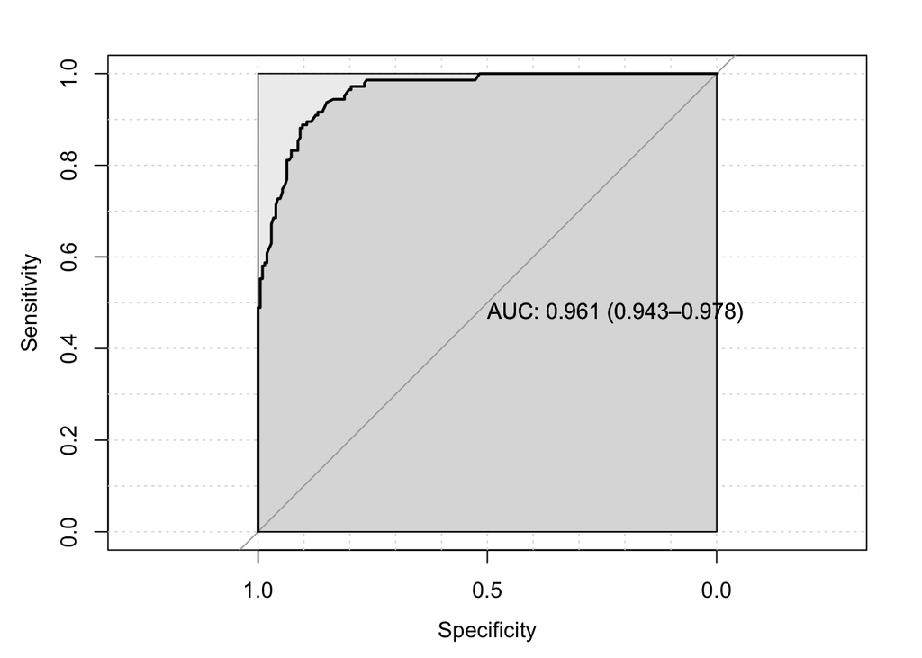

```r
# A curva ROC (Receiver Operating Characteristic) atesta o poder preditivo do modelo
# quando AUC (Area Under Curve) > 0.5
# o modelo perfeito teria AUC = 1
pROC::roc(m4$model$y, m4$fitted.values,
          smoothed = TRUE,
          # arguments for ci
          ci=TRUE, ci.alpha=0.9, stratified=FALSE,
          # arguments for plot
          plot=TRUE, auc.polygon=TRUE, max.auc.polygon=TRUE, grid=TRUE,
          print.auc=TRUE, show.thres=TRUE) -> mroc
```

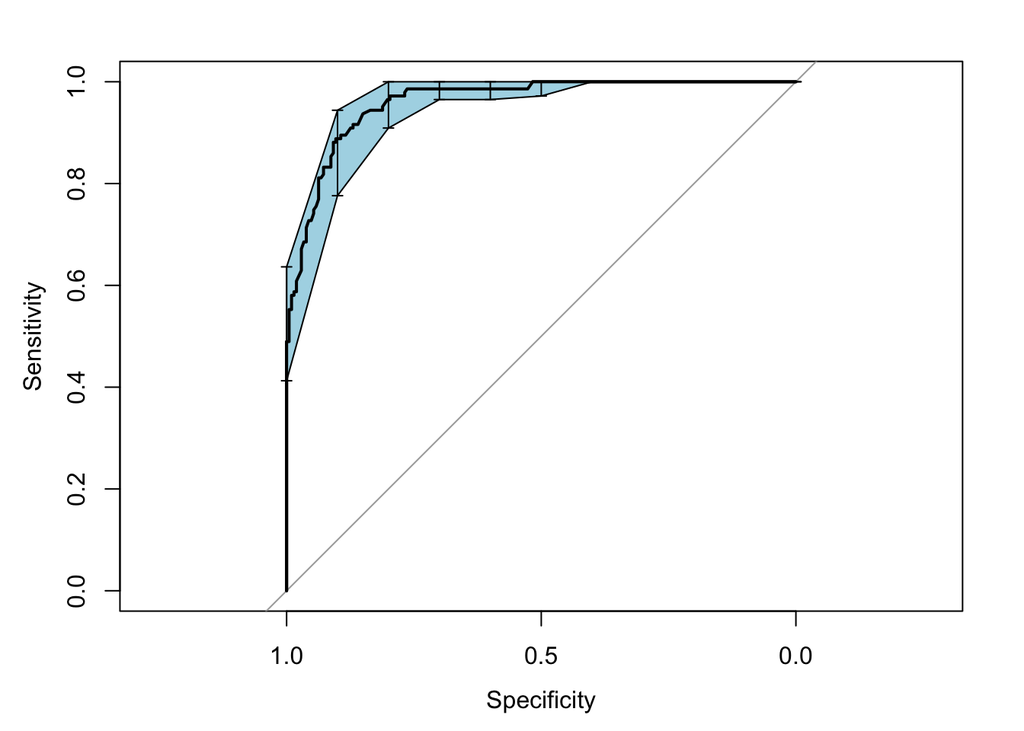

```r
plot(mroc)
sens.ci <- pROC::ci.se(mroc)
plot(sens.ci, type="shape", col="lightblue")
## Warning in plot.ci.se(sens.ci, type = "shape", col = "lightblue"): Low
## definition shape.
plot(sens.ci, type="bars")
```

## Voltando ao tema…

```r
data("coke", package="PoEdata")
coke.logit <- glm(coke~pratio+disp_coke+disp_pepsi,
              data=coke, family=binomial(link="logit"))
coke.logit %>% summary
```

```
##
## Call:
## glm(formula = coke ~ pratio + disp_coke + disp_pepsi, family = binomial(link = "logit"),
##     data = coke)
##
## Coefficients:
##             Estimate Std. Error z value Pr(>|z|)
## (Intercept)   1.9230     0.3258   5.902 3.59e-09 ***
## pratio       -1.9957     0.3146  -6.344 2.23e-10 ***
## disp_coke     0.3516     0.1585   2.218   0.0266 *
## disp_pepsi   -0.7310     0.1678  -4.356 1.33e-05 ***
## ---
## Signif. codes:  0 '***' 0.001 '**' 0.01 '*' 0.05 '.' 0.1 ' ' 1
##
## (Dispersion parameter for binomial family taken to be 1)
##
##     Null deviance: 1567.7  on 1139  degrees of freedom
## Residual deviance: 1418.9  on 1136  degrees of freedom
## AIC: 1426.9
##
## Number of Fisher Scoring iterations: 3
```

```r
coke.LPM <- lm(coke~pratio+disp_coke+disp_pepsi,
              data=coke)
coke.probit <- glm(coke~pratio+disp_coke+disp_pepsi,
              data=coke, family=binomial(link="probit"))
stargazer(coke.LPM, coke.probit, coke.logit,
  header=FALSE,
  title="Three binary choice models for the 'coke' dataset",
  type=.stargazertype,
  keep.stat="n",digits=4, single.row=FALSE,
  intercept.bottom=FALSE,
  model.names=FALSE,
  column.labels=c("LPM","probit","logit"))
```

```
##
## <table style="text-align:center"><caption><strong>Three binary choice models for the 'coke' dataset</strong></caption>
## <tr><td colspan="4" style="border-bottom: 1px solid black"></td></tr><tr><td style="text-align:left"></td><td colspan="3"><em>Dependent variable:</em></td></tr>
## <tr><td></td><td colspan="3" style="border-bottom: 1px solid black"></td></tr>
## <tr><td style="text-align:left"></td><td colspan="3">coke</td></tr>
## <tr><td style="text-align:left"></td><td>LPM</td><td>probit</td><td>logit</td></tr>
## <tr><td style="text-align:left"></td><td>(1)</td><td>(2)</td><td>(3)</td></tr>
## <tr><td colspan="4" style="border-bottom: 1px solid black"></td></tr><tr><td style="text-align:left">Constant</td><td>0.8902<sup>***</sup></td><td>1.1080<sup>***</sup></td><td>1.9230<sup>***</sup></td></tr>
## <tr><td style="text-align:left"></td><td>(0.0655)</td><td>(0.1925)</td><td>(0.3258)</td></tr>
## <tr><td style="text-align:left"></td><td></td><td></td><td></td></tr>
## <tr><td style="text-align:left">pratio</td><td>-0.4009<sup>***</sup></td><td>-1.1459<sup>***</sup></td><td>-1.9957<sup>***</sup></td></tr>
## <tr><td style="text-align:left"></td><td>(0.0613)</td><td>(0.1839)</td><td>(0.3146)</td></tr>
## <tr><td style="text-align:left"></td><td></td><td></td><td></td></tr>
## <tr><td style="text-align:left">disp_coke</td><td>0.0772<sup>**</sup></td><td>0.2172<sup>**</sup></td><td>0.3516<sup>**</sup></td></tr>
## <tr><td style="text-align:left"></td><td>(0.0344)</td><td>(0.0962)</td><td>(0.1585)</td></tr>
## <tr><td style="text-align:left"></td><td></td><td></td><td></td></tr>
## <tr><td style="text-align:left">disp_pepsi</td><td>-0.1657<sup>***</sup></td><td>-0.4473<sup>***</sup></td><td>-0.7310<sup>***</sup></td></tr>
## <tr><td style="text-align:left"></td><td>(0.0356)</td><td>(0.1010)</td><td>(0.1678)</td></tr>
## <tr><td style="text-align:left"></td><td></td><td></td><td></td></tr>
## <tr><td colspan="4" style="border-bottom: 1px solid black"></td></tr><tr><td style="text-align:left">Observations</td><td>1,140</td><td>1,140</td><td>1,140</td></tr>
## <tr><td colspan="4" style="border-bottom: 1px solid black"></td></tr><tr><td style="text-align:left"><em>Note:</em></td><td colspan="3" style="text-align:right"><sup>*</sup>p<0.1; <sup>**</sup>p<0.05; <sup>***</sup>p<0.01</td></tr>
## </table>
```

```r
# percebam que o Colonescu faz uma validação interna
tble <- data.frame(true=coke$coke, predicted=round(fitted(coke.logit))) %>% table
(tble/rowSums(tble)) %>% round(4) * 100
```

```
##     predicted
## true     0     1
##    0 80.48 19.52
##    1 51.57 48.43
```

## 1.4 16.5 Multinomial Logit

```r
data("nels_small", package="PoEdata")
nels_small %>% head
```

```
##   psechoice hscath grades faminc famsiz parcoll female black
## 1         2      0   9.08   62.5      5       0      0     0
## 2         2      0   8.31   42.5      4       0      1     0
## 3         3      0   7.42   62.5      4       0      1     0
## 4         3      0   7.42   62.5      4       0      1     0
## 5         3      0   7.42   62.5      4       0      1     0
## 6         3      0   7.46   12.5      2       0      1     0
```

```r
library(nnet)
nels.multinom <- multinom(psechoice~grades, data=nels_small)
nels.multinom %>% summary
```

```
## Call:
## multinom(formula = psechoice ~ grades, data = nels_small)
##
## Coefficients:
##   (Intercept)     grades
## 2    2.505273 -0.3086404
## 3    5.770170 -0.7062468
##
## Std. Errors:
##   (Intercept)     grades
## 2   0.4183944 0.05228532
## 3   0.4043290 0.05292638
##
## Residual Deviance: 1750.626
## AIC: 1758.626
```

```r
pred <- predict(nels.multinom, nels_small, "probs")
pred %>% apply(1, which.max) -> yhat
data.frame(y = nels_small$psechoice, yhat = yhat) %>% table -> t
(t/rowSums(t)) %>% round(4) * 100
```

```
##    yhat
## y       1     3
##   1 52.70 47.30
##   2 32.67 67.33
##   3 11.20 88.80
```

## 1.5 16.9 The Tobit, or Censored Data Model

Dados censurados -> limitados à esquerda e/ou à direita

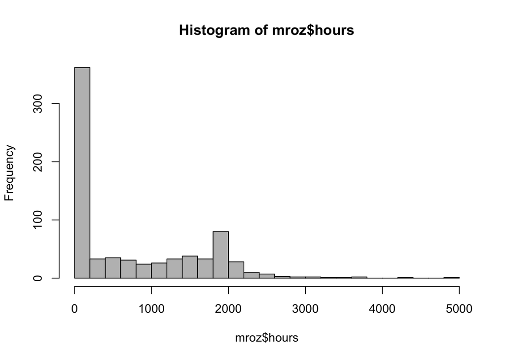

```r
data("mroz", package="PoEdata")
hist(mroz$hours, breaks=20, col="grey")
```

```r
mroz %>% head
```

```
##   taxableinc federaltax hsiblings hfathereduc hmothereduc siblings lfp hours
## 1      12200       1494         1          14          16        4   1  1610
## 2      18000       2615         8           7           3        0   1  1656
## 3      24000       3957         4           7          10        2   1  1980
## 4      16400       2279         6           7          12        5   1   456
## 5      10000       1063         3           7           7        7   1  1568
## 6       6295        370         8           7           7        4   1  2032
##   kidsl6 kids618 age educ   wage wage76 hhours hage heduc   hwage faminc    mtr
## 1      1       0  32   12 3.3540   2.65   2708   34    12  4.0288  16310 0.7215
## 2      0       2  30   12 1.3889   2.65   2310   30     9  8.4416  21800 0.6615
## 3      1       3  35   12 4.5455   4.04   3072   40    12  3.5807  21040 0.6915
## 4      0       3  34   12 1.0965   3.25   1920   53    10  3.5417   7300 0.7815
## 5      1       2  31   14 4.5918   3.60   2000   32    12 10.0000  27300 0.6215
## 6      0       0  54   12 4.7421   4.70   1040   57    11  6.7106  19495 0.6915
##   mothereduc fathereduc unemployment largecity exper
## 1         12          7          5.0         0    14
## 2          7          7         11.0         1     5
## 3         12          7          5.0         0    15
## 4          7          7          5.0         0     6
## 5         12         14          9.5         1     7
## 6         14          7          7.5         1    33
```

```r
library(AER)
mroz.tobit <- tobit(hours~educ+exper+age+kidsl6, data=mroz, left = 0, dist = "gaussian")
sMrozTobit <- summary(mroz.tobit)
sMrozTobit
```

```
##
## Call:
## tobit(formula = hours ~ educ + exper + age + kidsl6, left = 0,
##     dist = "gaussian", data = mroz)
##
## Observations:
##          Total  Left-censored     Uncensored Right-censored
##            753            325            428              0
##
## Coefficients:
##              Estimate Std. Error z value Pr(>|z|)
## (Intercept) 1349.8763   386.2991   3.494 0.000475 ***
## educ          73.2910    20.4746   3.580 0.000344 ***
## exper         80.5353     6.2878  12.808  < 2e-16 ***
## age          -60.7678     6.8882  -8.822  < 2e-16 ***
## kidsl6      -918.9181   111.6607  -8.230  < 2e-16 ***
## Log(scale)     7.0332     0.0371 189.565  < 2e-16 ***
## ---
## Signif. codes:  0 '***' 0.001 '**' 0.01 '*' 0.05 '.' 0.1 ' ' 1
##
## Scale: 1134
##
## Gaussian distribution
## Number of Newton-Raphson Iterations: 4
## Log-likelihood: -3827 on 6 Df
## Wald-statistic: 243.3 on 4 Df, p-value: < 2.22e-16
```

```r
mroz.lm <- lm(hours~educ+exper+age+kidsl6,
                    data=mroz)
sMrozlm <- summary(mroz.lm)
sMrozlm
```

```
##
## Call:
## lm(formula = hours ~ educ + exper + age + kidsl6, data = mroz)
##
## Residuals:
##     Min      1Q  Median      3Q     Max
## -1916.6  -530.2  -153.6   522.5  3568.8
##
## Coefficients:
##             Estimate Std. Error t value Pr(>|t|)
## (Intercept) 1335.306    235.649   5.667 2.08e-08 ***
## educ          27.086     12.240   2.213   0.0272 *
## exper         48.040      3.642  13.191  < 2e-16 ***
## age          -31.308      3.961  -7.904 9.67e-15 ***
## kidsl6      -447.855     58.413  -7.667 5.48e-14 ***
## ---
## Signif. codes:  0 '***' 0.001 '**' 0.01 '*' 0.05 '.' 0.1 ' ' 1
##
## Residual standard error: 753 on 748 degrees of freedom
## Multiple R-squared:  0.2571, Adjusted R-squared:  0.2531
## F-statistic: 64.71 on 4 and 748 DF,  p-value: < 2.2e-16
```

```r
cbind(y = m[,1], yhat = m1$fitted.values %>% discretize(levels = 2) - 1) %>% as.data.frame() %>% table
```

```
##    yhat
## y     0   1
##   0 157 143
##   1 103  97
```

```r
m2 = glm(as.factor(y)~., data = m %>% as.data.frame, family = binomial("logit"))
m2 %>% summary
```

```
##
## Call:
## glm(formula = as.factor(y) ~ ., family = binomial("logit"), data = m %>%
##     as.data.frame)
##
## Coefficients:
##             Estimate Std. Error z value Pr(>|z|)
## (Intercept) -15.1597     2.0004  -7.578 3.50e-14 ***
## x1            2.2158     0.2799   7.916 2.46e-15 ***
## x2            0.2696     0.1931   1.397    0.163
## x3            4.1952     0.4336   9.675  < 2e-16 ***
## x4           -0.1398     0.1983  -0.705    0.481
## x5           -1.9420     0.2554  -7.603 2.90e-14 ***
## ---
## Signif. codes:  0 '***' 0.001 '**' 0.01 '*' 0.05 '.' 0.1 ' ' 1
##
## (Dispersion parameter for binomial family taken to be 1)
##
##     Null deviance: 673.01  on 499  degrees of freedom
## Residual deviance: 223.14  on 494  degrees of freedom
## AIC: 235.14
##
## Number of Fisher Scoring iterations: 7
```

```r
cbind(y = m[,1], yhat = m2$fitted.values %>% discretize(levels = 2) - 1) %>% as.data.frame() %>% table
```

```
##    yhat
## y     0   1
##   0 273  27
##   1  19 181
```